# Mushroom Data

Khang Pham, Don Pham

For this project, we are using the mushroom data from the UCI Machine Learning Repository. These data include 8124 samples corresponding to 23 species of gilled mushrooms in the Agaricus and Lepitoa family. Each sample is identified as either definitely edible or poisonous. The latter category includes both definitely poisonous and unknown edibility. There are 22 additional attributes for each mushroom. In the raw data, the value for each attribute is a letter. This letter corresponds to a value given in a chart provided with the data. The data are broken up into 6 tables, grouped by the attribute types.

To make the data easier to work with, we join the six tables into one dataframe in R. Before we import the data, we must add the column names to the raw data files and save as CSV. We then use a data wrangling workflow in R to import the six CSV files and join them into one dataframe.

```r
source('../01 Data/data.R', echo = TRUE)
```

```
##
## > setwd("~/Documents/School/2015spring/DataVis/DV_FinalProject/01 Data")
##
## > file_path_caps <- "caps.csv"
##
## > file_path_gills <- "gills.csv"
##
## > file_path_other <- "other.csv"
##
## > file_path_rings <- "rings.csv"
##
## > file_path_stalks <- "stalks.csv"
##
## > file_path_veils <- "veils.csv"
##
## > df <- read.csv(file_path_other, stringsAsFactors = FALSE) %>%
## +     full_join(., read.csv(file_path_caps, stringsAsFactors = FALSE),
## +         by  .... [TRUNCATED]
```

We use a modified version of Dr. Cannata’s data reformatting script to format the data. The script replaces all periods in the column names with underscores. We use gsub to replace the letters with their corresponding values. For example, a value of “k” in a color attribute should be changed to “black”. The script will also export the dataframe as a CSV file. We then upload the reformatted data to Oracle.

```r
source('../02 Data Wrangling/reformatting.R', echo = TRUE)
```

```
##
## > setwd("~/Documents/School/2015spring/DataVis/DV_FinalProject/01 Data")
##
## > names(df) <- gsub("\\.+", "_", names(df))
##
## > df$edible_or_poisonous <- gsub("^e$", "edible", df$edible_or_poisonous)
##
## > df$edible_or_poisonous <- gsub("^p$", "poisonous",
## +     df$edible_or_poisonous)
##
## > df$cap_shape <- gsub("^b$", "bell", df$cap_shape)
##
## > df$cap_shape <- gsub("^c$", "conical", df$cap_shape)
##
## > df$cap_shape <- gsub("^x$", "convex", df$cap_shape)
##
## > df$cap_shape <- gsub("^f$", "flat", df$cap_shape)
##
## > df$cap_shape <- gsub("^k$", "knobbed", df$cap_shape)
##
## > df$cap_shape <- gsub("^s$", "sunken", df$cap_shape)
##
## > df$cap_surface <- gsub("^f$", "fibrous", df$cap_surface)
##
## > df$cap_surface <- gsub("^g$", "grooves", df$cap_surface)
##
## > df$cap_surface <- gsub("^y$", "scaly", df$cap_surface)
##
## > df$cap_surface <- gsub("^s$", "smooth", df$cap_surface)
##
## > df$cap_color <- gsub("^n$", "brown", df$cap_color)
##
## > df$cap_color <- gsub("^b$", "buff", df$cap_color)
##
## > df$cap_color <- gsub("^c$", "cinnamon", df$cap_color)
##
## > df$cap_color <- gsub("^g$", "gray", df$cap_color)
##
## > df$cap_color <- gsub("^r$", "green", df$cap_color)
##
```

[output cut: 274 more lines]

```
##  cap_color varchar2(4000),
##  gill_attachment varchar2(4000),
##  gill_spacing varchar2(4000),
##  gill_size varchar2(4000),
##  gill_color varchar2(4000),
##  ring_type varchar2(4000),
##  stalk_root varchar2(4000),
##  stalk_surface_above_ring varchar2(4000),
##  stalk_surface_below_ring varchar2(4000),
##  stalk_color_above_ring varchar2(4000),
##  stalk_color_below_ring varchar2(4000),
##  stalk_shape varchar2(4000),
##  veil_type varchar2(4000),
##  veil_color varchar2(4000)
##  );
```

In the following graphs, we show the number of mushrooms with a given attribute separated into two groups: poisonous mushrooms and edible mushrooms.

# Rank

The last column shows the rank of the cap colors in each group. Here, we found that the most popular color is brown, shared between both groups of edible and poisonous.

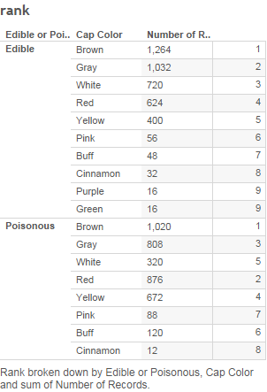

# Cap Color

We can see here that all green and purple capped mushrooms are edible.

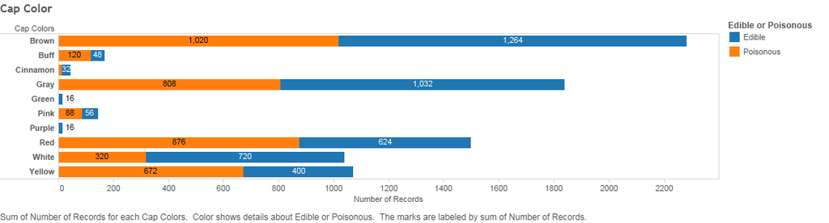

# Habitat

Here, we are showing the different types of habitats that the mushrrooms grow in. From this data, we found out that most of the mushrooms you find on paths you walk on are poisonous.

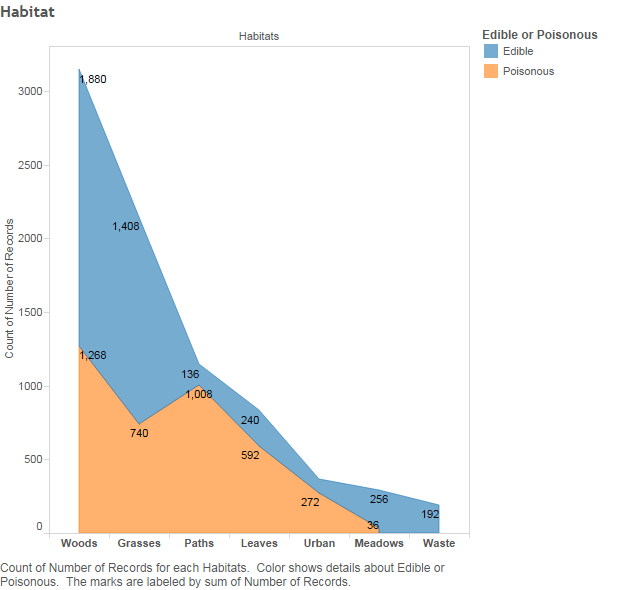

# Gill Color

The gills on the mushrooms are the ribs underneath the cap. We color-coded the colors to match the gill colors. Here we see that all of the buff colored gills are poisonous.

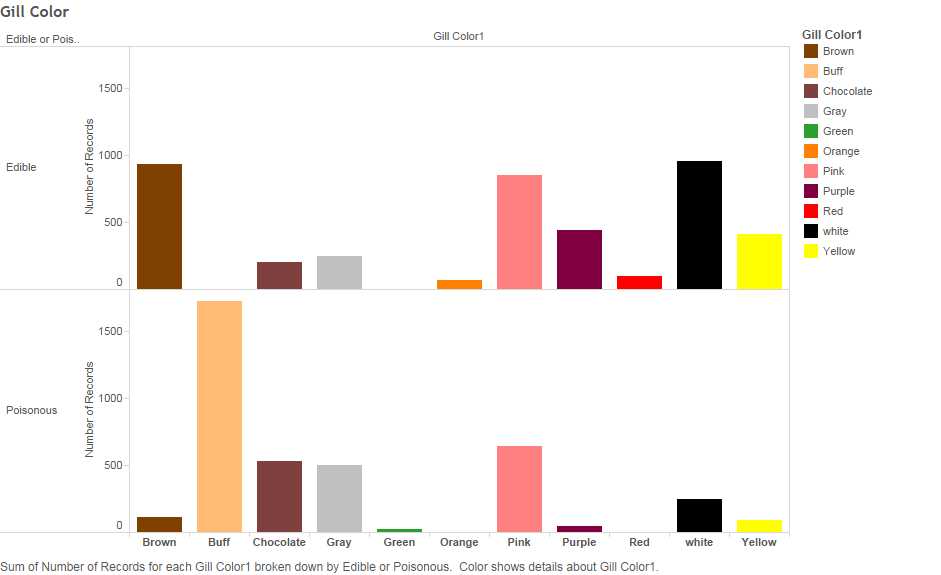

# Nth

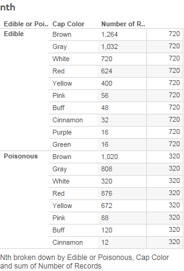

# Population

Population of the mushrooms is the size of the groups they grow in. The graph shows these groups in order from abundant to solitary.

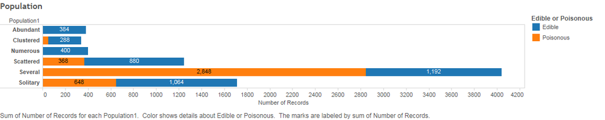

# Odors

This graph shows the odor that the different types of odor the mushrooms produce. We found out that the nice smelling mushrooms are edible, while the bad smelling ones are poisonous.

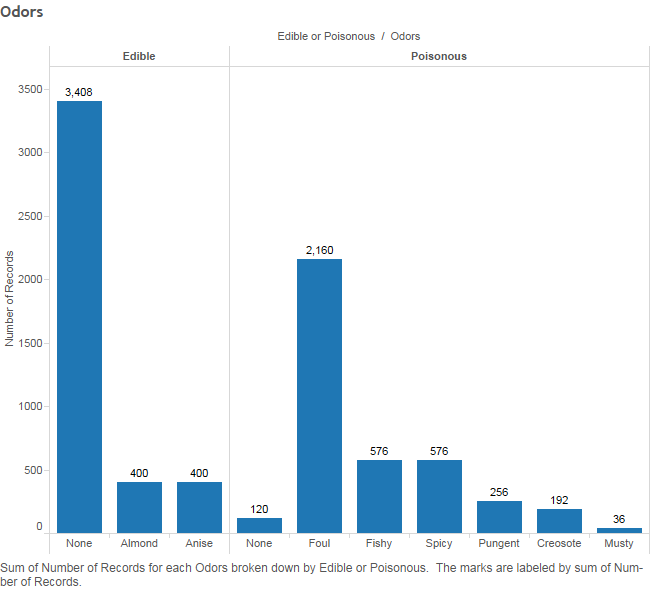

# Spore Print

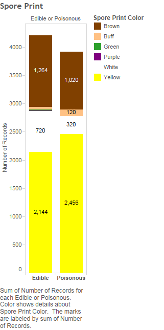

# Habitats and Cap Color

Here we combined habitats and color. We can see that 100% of white mushrooms found in urban areas are poisonous. Similarly, if the cap color is red and the habitat is either leaves or paths, the mushroom is likely to be poisonous. Yellow capped mushrooms growing in meadows are edible, as are any mushroom growing in waste.

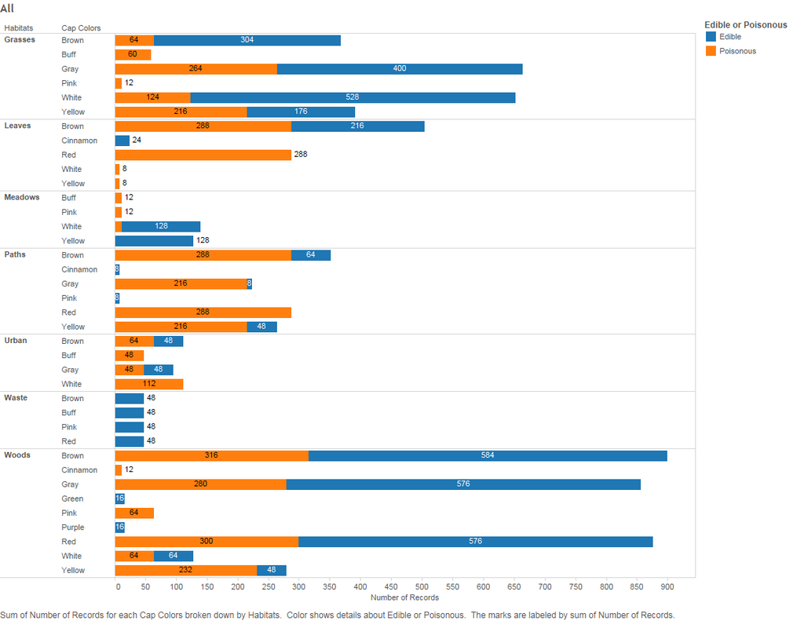